# Lecture 2: Properties of the OLS estimator

Economics 527: Econometric Methods

Author

Vadim Marmer, UBC

# Model and assumptions

## Where the first lecture ended

- The first lecture produced the estimator and stopped there:
  $$\hat\beta = (X^\top X)^{-1} X^\top Y
  = \left(\sum_{i=1}^n X_i X_i^\top\right)^{-1}\sum_{i=1}^n X_i Y_i,$$
  the unique minimiser of $\sum_{i=1}^n (Y_i - X_i^\top b)^2$.
- Nothing so far says whether it is a good estimator.
- $\hat\beta$ is a function of the sample, so it is random, and in general it will not equal $\beta$.
- Three questions, taken in this order: whether $\hat\beta$ is right on average, how far it moves from sample to sample, and whether a better estimator of the same kind exists.

## Model in matrix form

- Stack the $n$ observations, as in the first lecture:
  $$\underset{n\times1}{Y} = \begin{pmatrix} Y_1 \\ \vdots \\ Y_n \end{pmatrix},\qquad
  \underset{n\times k}{X} = \begin{pmatrix} X_1^\top \\ \vdots \\ X_n^\top \end{pmatrix},\qquad
  \underset{n\times1}{U} = \begin{pmatrix} U_1 \\ \vdots \\ U_n \end{pmatrix}.$$
- The $n$ scalar equations $Y_i = X_i^\top\beta + U_i$ become one:
  $$\underset{n\times1}{Y} = \underset{n\times k}{X}\ \underset{k\times1}{\beta} + \underset{n\times1}{U}.$$
- $\beta$ is fixed and unknown. $X$, $Y$ and $U$ are random, and $U$ is not observed.

## Four assumptions

- **Assumption 1.** $Y = X\beta + U$ for some $\beta \in \mathbb{R}^k$.
- **Assumption 2.** $\mathrm{E}\left[U \mid X\right] = 0$.
- **Assumption 3.** $\mathrm{Var}\left(U \mid X\right) = \sigma^2 I_n$ for some $\sigma^2 > 0$.
- **Assumption 4.** $\operatorname{rank}(X) = k$.

# Unbiasedness

## What unbiased means

- $\hat\beta$ is a function of the sample, hence a random vector:
  $$\hat\beta(\omega) = \left(\sum_{i=1}^n X_i(\omega) X_i(\omega)^\top\right)^{-1}\sum_{i=1}^n X_i(\omega) Y_i(\omega).$$
- With a continuously distributed error, $\mathrm{P}(\hat\beta = \beta) = 0$. Hitting $\beta$ exactly is not the standard.
- **Definition.** An estimator $\hat\theta$ of $\theta$ is **unbiased** if $\mathrm{E}\left[\hat\theta\right] = \theta$, and **conditionally unbiased given $X$** if
  $$\mathrm{E}\left[\hat\theta \mid X\right] = \theta,$$
  whatever the true value of $\theta$: the estimator is a rule that does not know $\theta$, and the equality must hold for every value $\theta$ could take.
- The conditional statement is the stronger one, and it is the one this lecture proves.

## Sampling error

- Substitute Assumption 1 into the estimator; Assumption 4 is what makes $(X^\top X)^{-1}$ exist:
  $$\begin{aligned}
  \hat\beta &= (X^\top X)^{-1} X^\top Y \\
  &= (X^\top X)^{-1} X^\top (X\beta + U) \\
  &= \underbrace{(X^\top X)^{-1} X^\top X}_{=\, I_k}\, \beta + (X^\top X)^{-1} X^\top U.
  \end{aligned}$$
- The first term produces $\beta$, and we have signal+noise decomposition:
  $$\boxed{\ \hat\beta = \underbrace{\beta}_{\text{signal}} + \underbrace{{\color{blue}(X^\top X)^{-1} X^\top U}}_{\text{noise}}\ }$$
- Everything in this section and the next is a statement about the noise term.

## Taking expectations, first attempt

- Take expectations of the sampling error:
  $$\mathrm{E}\left[\hat\beta\right] = \beta + \mathrm{E}\left[{\color{blue}(X^\top X)^{-1} X^\top U}\right].$$
- Suppose only that $\mathrm{E}\left[X_i U_i\right] = 0$ for every $i$. Then
  $$\mathrm{E}\left[X^\top U\right] = \mathrm{E}\left[\sum_{i=1}^n X_i U_i\right] = \sum_{i=1}^n \mathrm{E}\left[X_i U_i\right] = 0.$$
- That is not enough, because in general
  $$\mathrm{E}\left[(X^\top X)^{-1} X^\top U\right] \;\text{ need not equal }\; \mathrm{E}\left[(X^\top X)^{-1}\right]\,\mathrm{E}\left[X^\top U\right].$$
- The two factors are built from the same $X$, and once $\mathrm{E}\left[U \mid X\right]$ is not zero, the expectation of their product need not factor.

## Expectation of a ratio

- The one-regressor case makes the failure visible:
  $$\mathrm{E}\left[\frac{\sum_i X_i U_i}{\sum_i X_i^2}\right] \;\text{ need not equal }\; \frac{\mathrm{E}\left[\sum_i X_i U_i\right]}{\mathrm{E}\left[\sum_i X_i^2\right]} = 0.$$
- In general the expectation of a ratio is not the ratio of expectations. For any two scalar random variables $Z$ and $S$,
  $$\mathrm{E}\left[\frac{Z}{S}\right] = \iint \frac{z}{s}\, f_{Z,S}(z,s)\, dz\, ds
  \;\text{ need not equal }\;
  \frac{\int z f_Z(z)\, dz}{\int s f_S(s)\, ds} = \frac{\mathrm{E}\left[Z\right]}{\mathrm{E}\left[S\right]}.$$
- The way out is to condition on $X$, which turns $(X^\top X)^{-1}X^\top$ into a known matrix.

## Conditional unbiasedness: the claim

- **Claim.** Under Assumptions 1, 2 and 4,
  $$\mathrm{E}\left[\hat\beta \mid X\right] = \beta.$$
- Assumption 3 is not used. Unbiasedness does not depend on the variance of the errors.

## Proof of conditional unbiasedness

- Condition the sampling error on $X$:
  $$\begin{aligned}
  \mathrm{E}\left[\hat\beta \mid X\right] &= \mathrm{E}\left[\beta + (X^\top X)^{-1}X^\top U \mid X\right] \\
  &= \beta + \mathrm{E}\left[(X^\top X)^{-1}X^\top U \mid X\right] \\
  &= \beta + (X^\top X)^{-1}X^\top \underbrace{\mathrm{E}\left[U \mid X\right]}_{=\,0 \text{ by Assumption 2}} \\
  &= \beta.
  \end{aligned}$$
- The third line takes out what is known, as in the first lecture. Given $X$, the matrix $(X^\top X)^{-1}X^\top$ is known and comes out of the expectation.

## From conditional to unconditional

- The law of iterated expectations, from the first lecture, finishes the proof:
  $$\mathrm{E}\left[\hat\beta\right] = \mathrm{E}\left[\mathrm{E}\left[\hat\beta \mid X\right]\right] = \mathrm{E}\left[\beta\right] = \beta.$$
- Conditional unbiasedness implies unbiasedness whenever the unconditional mean exists. The converse does not hold.

## A weaker condition

- Replace Assumption 2 by
  $$\mathrm{E}\left[X_i U_i\right] = 0 \quad \text{for all } i,$$
  which, together with $\mathrm{E}\left[U_i\right] = 0$, says that each regressor is uncorrelated with the error.
- $\beta$ is still identified under this condition.
- It is not enough for unbiasedness:
  $$\mathrm{E}\left[\hat\beta\right] = \beta + \underbrace{\mathrm{E}\left[(X^\top X)^{-1}X^\top U\right]}_{\text{need not be } 0}.$$
- So $\hat\beta$ need not be unbiased. The noise term is a nonlinear function of $X$ and $U$, and once $\mathrm{E}\left[U \mid X\right]$ is not zero, nothing forces its mean to vanish.

# Variance of a random vector

## Definition

- For a random vector $V$ that is $n \times 1$ with finite second moments, and with $\mathrm{E}\left[V\right] = (\mathrm{E}\left[V_1\right], \ldots, \mathrm{E}\left[V_n\right])^\top$,
  $$\mathrm{Var}\left(V\right) = \mathrm{E}\left[\underset{n\times 1}{(V - \mathrm{E}\left[V\right])}\ \underset{1\times n}{(V - \mathrm{E}\left[V\right])^\top}\right] \qquad (n \times n).$$
- The product inside is an outer product, not an inner product, so the result is a matrix rather than a number.

## Entry by entry

- Entry $(i,j)$ is $\mathrm{E}\left[(V_i - \mathrm{E}\left[V_i\right])(V_j - \mathrm{E}\left[V_j\right])\right]$, so
  $$\mathrm{Var}\left(V\right) = \begin{pmatrix}
  \mathrm{Var}\left(V_1\right) & \mathrm{Cov}\left(V_1, V_2\right) & \cdots & \mathrm{Cov}\left(V_1, V_n\right) \\
  \mathrm{Cov}\left(V_2, V_1\right) & \mathrm{Var}\left(V_2\right) & & \vdots \\
  \vdots & & \ddots & \\
  \mathrm{Cov}\left(V_n, V_1\right) & \cdots & & \mathrm{Var}\left(V_n\right)
  \end{pmatrix}.$$
- The variances sit on the diagonal and the covariances off it.

## Symmetry

- $\mathrm{Var}\left(V\right)^\top = \mathrm{Var}\left(V\right)$, because $\mathrm{Cov}\left(V_i, V_j\right) = \mathrm{Cov}\left(V_j, V_i\right)$.
- The same statement from the definition, using that the transpose passes through the expectation, and then $(AB)^\top = B^\top A^\top$:
  $$\mathrm{Var}\left(V\right)^\top = \mathrm{E}\left[\big((V - \mathrm{E}\left[V\right])(V - \mathrm{E}\left[V\right])^\top\big)^\top\right] = \mathrm{E}\left[(V - \mathrm{E}\left[V\right])(V - \mathrm{E}\left[V\right])^\top\right] = \mathrm{Var}\left(V\right).$$

## Positive semidefiniteness

- **Claim.** $\mathrm{Var}\left(V\right)$ is positive semidefinite.
- **Proof.** Take any non-random $a \in \mathbb{R}^n$ and set $W = a^\top (V - \mathrm{E}\left[V\right])$, a scalar. Then
  $$\begin{aligned}
  a^\top \mathrm{Var}\left(V\right) a &= a^\top \mathrm{E}\left[(V - \mathrm{E}\left[V\right])(V - \mathrm{E}\left[V\right])^\top\right] a \\
  &= \mathrm{E}\left[\underbrace{a^\top (V - \mathrm{E}\left[V\right])}_{W}\ \underbrace{(V - \mathrm{E}\left[V\right])^\top a}_{W}\right] \\
  &= \mathrm{E}\left[W^2\right] \;\ge\; 0.
  \end{aligned}$$
- The constant $a$ moves inside the expectation because expectation is linear.
- This is the argument the first lecture used for $\mathrm{E}\left[X_i X_i^\top\right]$, with $W_i = X_i^\top c$.

## When it is positive definite

- For $a \neq 0$, with $W = a^\top (V - \mathrm{E}\left[V\right])$ as above, track the equality case:
  $$a^\top \mathrm{Var}\left(V\right) a = 0 \iff \mathrm{E}\left[W^2\right] = 0 \iff a^\top (V - \mathrm{E}\left[V\right]) = 0,$$
  that is,
  $$a_1 (V_1 - \mathrm{E}\left[V_1\right]) + \cdots + a_n (V_n - \mathrm{E}\left[V_n\right]) = 0.$$
- So $\mathrm{Var}\left(V\right)$ is positive definite exactly when no non-zero linear combination of $V_1, \ldots, V_n$ is constant, that is, when no exact linear relation holds among the centred variables $V_i - \mathrm{E}\left[V_i\right]$.

## Variance under a linear map

- **Claim.** For a non-random $m \times n$ matrix $\Gamma$,
  $$\boxed{\ \mathrm{Var}\left(\Gamma V\right) = \Gamma \mathrm{Var}\left(V\right) \Gamma^\top \ } \qquad (m \times m).$$
- **Proof.** $\mathrm{E}\left[\Gamma V\right] = \Gamma \mathrm{E}\left[V\right]$, so
  $$\begin{aligned}
  \mathrm{Var}\left(\Gamma V\right) &= \mathrm{E}\left[\big(\Gamma V - \Gamma\mathrm{E}\left[V\right]\big)\big(\Gamma V - \Gamma\mathrm{E}\left[V\right]\big)^\top\right] \\
  &= \mathrm{E}\left[\Gamma (V - \mathrm{E}\left[V\right]) (V - \mathrm{E}\left[V\right])^\top \Gamma^\top\right] \\
  &= \Gamma \mathrm{E}\left[(V - \mathrm{E}\left[V\right])(V - \mathrm{E}\left[V\right])^\top\right] \Gamma^\top = \Gamma \mathrm{Var}\left(V\right) \Gamma^\top,
  \end{aligned}$$
  using $(AB)^\top = B^\top A^\top$ on the second factor, and linearity to move the non-random $\Gamma$ and $\Gamma^\top$ outside the expectation.
- Check against the scalar case: with $m = n = 1$ this is $\mathrm{Var}\left(\gamma V\right) = \gamma^2 \mathrm{Var}\left(V\right)$.

## Adding a constant

- For a non-random $\alpha$ that is $m \times 1$,
  $$\mathrm{Var}\left(\alpha + \Gamma V\right) = \mathrm{Var}\left(\Gamma V\right) = \Gamma \mathrm{Var}\left(V\right) \Gamma^\top.$$
- The constant shifts the mean, so the deviations from the mean are unchanged and it drops out.
- This is why $\beta$ will drop out of the variance of the sampling error.

## Conditional version

- The same definition with conditional expectations throughout:
  $$\mathrm{Var}\left(V \mid X\right) = \mathrm{E}\left[\big(V - \mathrm{E}\left[V \mid X\right]\big)\big(V - \mathrm{E}\left[V \mid X\right]\big)^\top \,\Big|\, X\right].$$
- Everything above holds conditionally, with $\Gamma$ allowed to be a function of $X$. Given $X$, such a $\Gamma$ is known and comes out of the conditional expectation, by taking out what is known, as in the proof of unbiasedness.
- When the conditional mean is zero, the definition simplifies. Under Assumption 2,
  $$\mathrm{Var}\left(U \mid X\right) = \mathrm{E}\left[U U^\top \mid X\right].$$

# Variance of the OLS estimator

## Variance matrix of $\hat\beta$

- $\hat\beta$ is $k \times 1$, so $\mathrm{Var}\left(\hat\beta \mid X\right)$ is $k \times k$: the conditional variance of each estimated coefficient on the diagonal, the conditional covariances between them off it.
- Conditioning on $X$ again, for the same reason it worked for unbiasedness: it makes $(X^\top X)^{-1}X^\top$ a known matrix.

## Sandwich formula

- Start from the sampling error and name the matrix that multiplies $U$:
  $$\hat\beta = \beta + \underbrace{(X^\top X)^{-1} X^\top}_{\Gamma_X}\, U.$$
- $\beta$ is a constant and drops out, and $\Gamma_X$ is known given $X$, so the rule for a linear map applies:
  $$\begin{aligned}
  \mathrm{Var}\left(\hat\beta \mid X\right) &= \mathrm{Var}\left(\beta + \Gamma_X U \mid X\right) \\
  &= \mathrm{Var}\left(\Gamma_X U \mid X\right) \\
  &= \Gamma_X \mathrm{Var}\left(U \mid X\right) \Gamma_X^\top.
  \end{aligned}$$

## Sandwich formula written out

- Substituting $\Gamma_X = (X^\top X)^{-1}X^\top$, with $\Gamma_X^\top = X (X^\top X)^{-1}$ because $X^\top X$ and its inverse are symmetric:
  $$\boxed{\ \mathrm{Var}\left(\hat\beta \mid X\right) = (X^\top X)^{-1} X^\top\ \mathrm{Var}\left(U \mid X\right)\ X (X^\top X)^{-1}\ }$$
- The box uses Assumptions 1 and 4, and needs the errors to have finite conditional second moments, so that $\mathrm{Var}\left(U \mid X\right)$ exists. Assumption 2 enters only to write the middle factor as $\mathrm{E}\left[U U^\top \mid X\right]$.
- Apart from requiring $\mathrm{Var}\left(U \mid X\right)$ to exist, nothing yet has been assumed about the errors’ conditional variances or covariances.

## Assumption 3: homoskedasticity and no autocorrelation

- **Assumption 3.** $\mathrm{Var}\left(U \mid X\right) = \sigma^2 I_n$ for some $\sigma^2 > 0$, that is,
  $$\mathrm{Var}\left(U \mid X\right) = \begin{pmatrix} \sigma^2 & & 0 \\ & \ddots & \\ 0 & & \sigma^2 \end{pmatrix}.$$
- Read the diagonal: every error has the same conditional variance,
  $$\mathrm{Var}\left(U_1 \mid X\right) = \cdots = \mathrm{Var}\left(U_n \mid X\right) = \sigma^2.$$
- This is **homoskedasticity**. It rules out errors that are more variable at some values of the regressors than at others.
- Read the off-diagonal entries: for $i \neq j$, with the first equality by Assumption 2,
  $$\mathrm{Cov}\left(U_i, U_j \mid X\right) = \mathrm{E}\left[U_i U_j \mid X\right] = 0.$$
- The errors are conditionally uncorrelated across observations. This is **no autocorrelation**, also called no serial correlation.
- Assumption 3 is these two statements together, and nothing more. It does not say the errors are independent, and it does not say they are normal.

## Variance of OLS under Assumption 3

- Put $\mathrm{Var}\left(U \mid X\right) = \sigma^2 I_n$ into the sandwich:
  $$\begin{aligned}
  \mathrm{Var}\left(\hat\beta \mid X\right) &= (X^\top X)^{-1} X^\top\ \sigma^2 I_n\ X (X^\top X)^{-1} \\
  &= \sigma^2 (X^\top X)^{-1} \underbrace{X^\top X (X^\top X)^{-1}}_{=\, I_k} \\
  &= \sigma^2 (X^\top X)^{-1}.
  \end{aligned}$$
- Under Assumptions 1 to 4:
  $$\boxed{\ \mathrm{E}\left[\hat\beta \mid X\right] = \beta, \qquad \mathrm{Var}\left(\hat\beta \mid X\right) = \sigma^2 (X^\top X)^{-1}\ }$$
- This pair is the central result of the lecture.

## What $\sigma^2$ is

- From Assumptions 2 and 3 together,
  $$\sigma^2 = \mathrm{Var}\left(U_i \mid X\right) = \mathrm{E}\left[U_i^2 \mid X\right],$$
  and the law of iterated expectations gives
  $$\sigma^2 = \mathrm{E}\left[U_i^2\right] = \mathrm{Var}\left(U_i\right),$$
  the last step because $\mathrm{E}\left[U_i\right] = \mathrm{E}\left[\mathrm{E}\left[U_i \mid X\right]\right] = 0$ by Assumption 2.
- $\sigma^2$ is one unknown number, the same for every observation. Estimating it is a question for the next lecture.

## One regressor

- Take $k = 1$ and no intercept, so $Y_i = \beta X_i + U_i$ and $X$ is $n \times 1$. Then $X^\top X = \sum_i X_i^2$ and
  $$\mathrm{Var}\left(\hat\beta \mid X\right) = \frac{\sigma^2}{\sum_{i=1}^n X_i^2}.$$
- Two things move the variance. Noisier errors raise it. A larger $\sum_i X_i^2$ lowers it: with no intercept this is the sum of squares of the regressor about zero. With an intercept the same formula gives the variance of the slope, with $\sum_i (X_i - \bar X)^2$, the spread of the regressor about its mean, in place of $\sum_i X_i^2$.

## Why spread in the regressor helps

- With the regressor bunched together, many quite different slopes fit the data about equally well, so the estimate moves a lot from sample to sample.
- With the regressor spread out, the slope is pinned down.

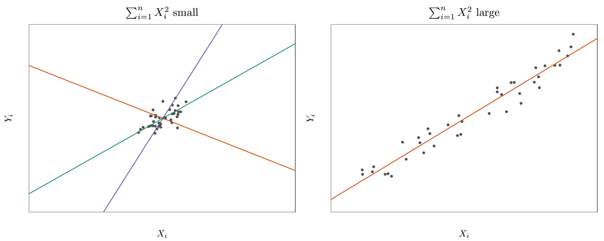

## Without homoskedasticity

- If the errors are heteroskedastic but still conditionally uncorrelated across observations, so that $\mathrm{Var}\left(U \mid X\right)$ is diagonal with entries that may depend on $X$,
  $$\mathrm{Var}\left(U \mid X\right) = \Omega = \begin{pmatrix} \sigma_1^2 & & 0 \\ & \ddots & \\ 0 & & \sigma_n^2 \end{pmatrix},$$
  the sandwich does not collapse. The middle factor becomes
  $$X^\top \Omega X = \begin{pmatrix} X_1 & \cdots & X_n \end{pmatrix} \Omega \begin{pmatrix} X_1^\top \\ \vdots \\ X_n^\top \end{pmatrix} = \sum_{i=1}^n \sigma_i^2 X_i X_i^\top,$$
  so
  $$\mathrm{Var}\left(\hat\beta \mid X\right) = (X^\top X)^{-1} \left(\sum_{i=1}^n \sigma_i^2 X_i X_i^\top\right) (X^\top X)^{-1}.$$
- Unbiasedness is untouched. Only the variance formula changes.

## Where each assumption was used

| Assumptions | What they deliver |
| --- | --- |
| 1, 2, 4 | $\mathrm{E}\left[\hat\beta \mid X\right] = \beta$, and $\mathrm{E}\left[\hat\beta\right] = \beta$ whenever that mean exists |
| 1, 4, finite conditional second moments | $\mathrm{Var}\left(\hat\beta \mid X\right) = \Gamma_X \mathrm{Var}\left(U \mid X\right) \Gamma_X^\top$, with $\Gamma_X = (X^\top X)^{-1}X^\top$ |
| 1, 3, 4 | $\mathrm{Var}\left(\hat\beta \mid X\right) = \sigma^2 (X^\top X)^{-1}$ |

# Gauss-Markov theorem

## Linear estimators

- **Definition.** An estimator of $\beta$ is **linear** if it can be written
  $$\tilde\beta = A Y$$
  for a matrix $A$ that is $k \times n$ and depends on $X$ alone, not on $Y$.
- OLS is linear, with $A = (X^\top X)^{-1} X^\top$.
- Given $X$, each entry of a linear estimator is a fixed linear combination of the observations on the dependent variable.

## Two more linear estimators

- **The two-point slope.** With $k = 1$ and $X_1 \neq X_n$,
  $$\tilde\beta = \frac{Y_n - Y_1}{X_n - X_1} = -\frac{1}{X_n - X_1} Y_1 + \frac{1}{X_n - X_1} Y_n.$$
  It uses two observations and throws the rest away.
- **Weighted least squares.** For a known $n \times n$ matrix $W$ that is symmetric and positive definite, and that may depend on $X$ but not on $Y$,
  $$\tilde\beta = (X^\top W X)^{-1} X^\top W\, Y.$$
  OLS is the case $W = I_n$, but for other choices of $W$ the estimator is different.

## Both are unbiased

- The two-point slope, assume $Y_i = \beta X_i + U_i$ and $\mathrm{E}\left[U_i \mid X\right] = 0$:
  $$\tilde\beta = \beta + \frac{U_n - U_1}{X_n - X_1}, \qquad \mathrm{E}\left[\tilde\beta \mid X\right] = \beta.$$
- Weighted least squares, assume $Y = X\beta + U$ and $\mathrm{E}\left[U \mid X\right] = 0$:
  $$\tilde\beta = \beta + (X^\top W X)^{-1} X^\top W\, U, \qquad \mathrm{E}\left[\tilde\beta \mid X\right] = \beta.$$
- Being linear and unbiased does not single OLS out. There are many conditionally unbiased linear estimators.
- One can show that under Assumptions 1-4,
  $$\mathrm{Var}\left(\tilde\beta \mid X\right) = \sigma^2 (X^\top W X)^{-1} X^\top W\, W X (X^\top W X)^{-1},$$
  which reduces to $\sigma^2 (X^\top X)^{-1}$ when $W = I_n$.
- Which of these matrices is smallest, and what smallest means for matrices, are the next questions.

## Comparison to settle

- For every linear conditionally unbiased $\tilde\beta$, compare the two conditional variance matrices:
  $$\underset{k\times k}{\mathrm{Var}\left(\tilde\beta \mid X\right)} - \underset{k\times k}{\mathrm{Var}\left(\hat\beta \mid X\right)} \ \overset{?}{\ge}\ 0.$$
- Here $\ge 0$ means positive semidefinite.

## Reading the matrix ordering

- If a $k \times k$ matrix $M$ is positive semidefinite, then $c^\top M c \ge 0$ for **every** $c \in \mathbb{R}^k$.
- Take $c$ to be the $j$th coordinate vector $e_j$, the vector with a $1$ in position $j$ and a $0$ everywhere else:
  $$e_j = (0, \ldots, 0, 1, 0, \ldots, 0)^\top, \qquad \text{the } 1 \text{ sitting in position } j.$$
- Writing the quadratic form out entry by entry, and using $(e_j)_l = 0$ for every $l \neq j$ and $(e_j)_j = 1$,
  $$e_j^\top M e_j = \sum_{l=1}^k \sum_{m=1}^k (e_j)_l\, M_{lm}\, (e_j)_m = M_{jj}.$$
- So every diagonal entry of a positive semidefinite matrix is non-negative.
- Suppose $M = \mathrm{Var}\left(\tilde\beta \mid X\right) - \mathrm{Var}\left(\hat\beta \mid X\right)\ge 0$ in the positive semidefinite sense. Then:
  $$\mathrm{Var}\left(\tilde\beta_j \mid X\right) \ \ge\ \mathrm{Var}\left(\hat\beta_j \mid X\right), \qquad j = 1, \ldots, k.$$

## Gauss-Markov theorem

- **Theorem.** Suppose Assumptions 1 to 4 hold:
  1. $Y = X\beta + U$ for some $\beta \in \mathbb{R}^k$;
  2. $\mathrm{E}\left[U \mid X\right] = 0$;
  3. $\mathrm{Var}\left(U \mid X\right) = \sigma^2 I_n$ for some $\sigma^2 > 0$;
  4. $\operatorname{rank}(X) = k$.
- Let $\hat\beta = (X^\top X)^{-1} X^\top Y$ be the OLS estimator.
- Let $\tilde\beta$ be any estimator that is
  - **linear**: $\tilde\beta = A Y$, with $A$ a $k \times n$ matrix depending on $X$ alone;
  - **conditionally unbiased**: $\mathrm{E}\left[\tilde\beta \mid X\right] = \beta$ for every value of $\beta$.
- Then
  $$\mathrm{Var}\left(\tilde\beta \mid X\right) - \mathrm{Var}\left(\hat\beta \mid X\right)\ge 0 \ \text{(positive semidefinite).}$$
- Meaning: OLS is the **best linear unbiased estimator** (BLUE): best in the sense above, linear in $Y$, conditionally unbiased, and an estimator of $\beta$.

## Proof, step 1: linearity and unbiasedness force $A X = I_k$

- Take conditional expectations of $\tilde\beta = A Y$:
  $$\begin{aligned}
  \beta = \mathrm{E}\left[\tilde\beta \mid X\right] &= \mathrm{E}\left[A(X\beta + U) \mid X\right] \\
  &= A X \beta + A \underbrace{\mathrm{E}\left[U \mid X\right]}_{=\,0 \text{ by Assumption 2}} \\
  &= A X \beta.
  \end{aligned}$$
- This must hold for every value of $\beta$ and all realizations of $X$, so
  $$\boxed{\ A X = I_k\ }$$
- Linearity plus conditional unbiasedness is exactly this one condition.
- In our examples:
  - OLS: $A = (X^\top X)^{-1} X^\top$, so:
    $$A X = (X^\top X)^{-1} X^\top X = I_k.$$
  - Weighted least squares: $A = (X^\top W X)^{-1} X^\top W$, so:
    $$A X = (X^\top W X)^{-1} X^\top W X = I_k.$$

## Proof, step 2: the covariance between $\tilde\beta$ and $\hat\beta$

- Using $A X = I_k$ for the general estimator:
  $$\tilde\beta = A X \beta + A U = \beta + A U.$$
- Therefore:
  $$\begin{align*}
  \tilde\beta - \beta &= A U.
  \end{align*}$$
- For OLS:
  $$\hat\beta - \beta = (X^\top X)^{-1} X^\top U.$$
- Consider the covariance between $\tilde\beta$ and $\hat\beta$:
  $$\begin{aligned}
  \mathrm{Cov}\left(\tilde\beta, \hat\beta \mid X\right)
  &= \mathrm{E}\left[\big(\tilde\beta - \beta\big)\big(\hat\beta - \beta\big)^\top \,\Big|\, X\right] \\
  &= \mathrm{E}\left[\underbrace{A U}_{\tilde\beta - \beta}\, \underbrace{U^\top X (X^\top X)^{-1}}_{(\hat\beta - \beta)^\top} \,\big|\, X\right] \\
  &= A\, \underbrace{\mathrm{E}\left[U U^\top \mid X\right]}_{=\,\sigma^2 I_n \text{ by Assumptions 2 and 3}}\, X (X^\top X)^{-1} \\
  &= \sigma^2 \underbrace{A X}_{=\, I_k} (X^\top X)^{-1} \\
  &= \sigma^2 (X^\top X)^{-1}.
  \end{aligned}$$
- The right-hand side is $\mathrm{Var}\left(\hat\beta \mid X\right)$, so
  $$\boxed{\ \mathrm{Cov}\left(\tilde\beta, \hat\beta \mid X\right) = \mathrm{Var}\left(\hat\beta \mid X\right)\ }$$
- Every linear conditionally unbiased estimator has the same covariance with OLS, namely the variance of OLS itself.

## Proof, step 3: the difference of the variances

- Expand the variance of the difference:
  $$\begin{aligned}
  \mathrm{Var}\left(\tilde\beta - \hat\beta \mid X\right) &= \mathrm{Var}\left(\tilde\beta \mid X\right) + {\color{blue}\mathrm{Var}\left(\hat\beta \mid X\right)} \\
  &\quad- {\color{blue}\mathrm{Cov}\left(\tilde\beta, \hat\beta \mid X\right)} - {\color{blue}\mathrm{Cov}\left(\hat\beta, \tilde\beta \mid X\right)}\\
  &= \mathrm{Var}\left(\tilde\beta \mid X\right) + {\color{blue}\mathrm{Var}\left(\hat\beta \mid X\right)} \\
  &\quad - \underbrace{\color{blue}\mathrm{Var}\left(\hat\beta \mid X\right)}_{=\mathrm{Cov}\left(\tilde\beta, \hat\beta \mid X\right)} - \underbrace{\color{blue}\mathrm{Var}\left(\hat\beta \mid X\right)}_{=\mathrm{Cov}\left(\hat\beta, \tilde\beta \mid X\right)^\top} \\
  &= \mathrm{Var}\left(\tilde\beta \mid X\right) - \mathrm{Var}\left(\hat\beta \mid X\right).
  \end{aligned}$$
- Therefore:
  $$0\leq \mathrm{Var}\left(\tilde\beta - \hat\beta \mid X\right) = \mathrm{Var}\left(\tilde\beta \mid X\right) - \mathrm{Var}\left(\hat\beta \mid X\right).$$

## Uniqueness

- Suppose some linear conditionally unbiased $\tilde\beta$ attains the same variance matrix. By the identity of step 3,
  $$\mathrm{Var}\left(\tilde\beta \mid X\right) = \mathrm{Var}\left(\hat\beta \mid X\right)
  \quad\Longrightarrow\quad
  \mathrm{Var}\left(\tilde\beta - \hat\beta \mid X\right) = 0.$$
- A random vector with zero conditional variance equals its conditional mean (the equality case of positive semidefiniteness, one coordinate at a time), so
  $$\tilde\beta - \hat\beta = \delta(X)$$
  for some function of $X$ alone.
- Both are conditionally unbiased, so taking conditional expectations,
  $$\underbrace{\mathrm{E}\left[\tilde\beta \mid X\right]}_{=\,\beta} = \underbrace{\mathrm{E}\left[\hat\beta \mid X\right]}_{=\,\beta} + \delta(X)
  \quad\Longrightarrow\quad \delta(X) = 0.$$
- Therefore $\tilde\beta = \hat\beta$.

## Where Assumption 3 was used

- Assumption 3 entered in step 2, where $\mathrm{E}\left[U U^\top \mid X\right]$ was replaced by $\sigma^2 I_n$, and again when $\sigma^2 (X^\top X)^{-1}$ was recognised as $\mathrm{Var}\left(\hat\beta \mid X\right)$. Without it the cancellation that produced $\sigma^2 A X$ fails, and the covariance need not equal the variance of OLS.
- If Assumption 3 fails, OLS is still unbiased but need not be best: Assumption 3 is sufficient for efficiency, not necessary.

## If Assumption 3 fails: generalised least squares

- Suppose now that $\mathrm{Var}\left(U \mid X\right) = \Omega$ for a known positive definite $\Omega$, not necessarily diagonal, with $\Omega \neq \sigma^2 I_n$ for every $\sigma^2 > 0$.
- Let $\Omega^{-1/2}$ be the symmetric positive definite matrix with $\Omega^{-1/2}\Omega^{-1/2} = \Omega^{-1}$.
  - It is built from the eigenvalue decomposition $\Omega^{-1/2} = C \Lambda^{-1/2} C^\top$.
- Multiply the model through by $\Omega^{-1/2}$:
  $$\begin{align*}
  &\underbrace{\Omega^{-1/2} Y}_{Y^*} = \underbrace{\Omega^{-1/2} X}_{X^*} \beta + \underbrace{\Omega^{-1/2} U}_{U^*}\\
  &Y^* = X^* \beta + U^*,\\
  & \mathrm{E}\left[U^* \mid X\right] = 0,\\
  & \mathrm{Var}\left(U^* \mid X\right) = \Omega^{-1/2} \Omega \Omega^{-1/2} = I_n.
  \end{align*}$$
- The transformed model satisfies all four assumptions, so Gauss-Markov applies to it.
- OLS on the transformed model is the best linear unbiased estimator:
  $$\hat\beta^* = (X^{*\top} X^*)^{-1} X^{*\top} Y^* = (X^\top \Omega^{-1} X)^{-1} X^\top \Omega^{-1} Y,$$
  which is weighted least squares with $W = \Omega^{-1}$. This is the **GLS estimator**: generalized least squares.
- Suppose $\mathrm{E}\left[U_i^2 \mid X\right] = \sigma_i^2$ and $\mathrm{E}\left[U_i U_j \mid X\right] = 0$ for $i \neq j$, so that
  $$\Omega = \begin{pmatrix} \sigma_1^2 & & 0 \\ & \ddots & \\ 0 & & \sigma_n^2 \end{pmatrix}.$$
- Then the GLS estimator is:
  $$\hat\beta^* = (X^\top \Omega^{-1} X)^{-1} X^\top \Omega^{-1} Y = \left(\sum_{i=1}^n \frac{X_i X_i^\top}{\sigma_i^2}\right)^{-1} \sum_{i=1}^n \frac{X_i Y_i}{\sigma_i^2}.$$
  Observations with larger $\sigma_i^2$ get less weight, and those with smaller $\sigma_i^2$ get more weight.
- This is equivalent transforming the data by scaling each observation $i$ by its $\sigma_i$:

  $$\frac{Y_i}{\sigma_i} = \frac{X_i^\top}{\sigma_i} \beta + \frac{U_i}{\sigma_i}, \qquad i = 1, \ldots, n,$$
  so that $\mathrm{Var}\left(U_i / \sigma_i \mid X\right) = 1$ for every $i$.
- In practice $\Omega$ is not known.

# Summary

## Summary: efficiency

- **Gauss-Markov.** Under Assumptions 1 to 4, OLS has the smallest conditional variance among all estimators that are linear in $Y$ and conditionally unbiased, whatever the value of $\beta$. For every such $\tilde\beta$, the difference of the two conditional variance matrices is positive semidefinite:
  $$\mathrm{Var}\left(\tilde\beta \mid X\right) - \mathrm{Var}\left(\hat\beta \mid X\right) \ \ge\ 0,$$
  so in particular $\mathrm{Var}\left(\tilde\beta_j \mid X\right) \ge \mathrm{Var}\left(\hat\beta_j \mid X\right)$ for every coefficient.
- **The proof.** Linearity and conditional unbiasedness force $A X = I_k$. Assumption 3 then makes $\mathrm{Cov}\left(\tilde\beta, \hat\beta \mid X\right) = \mathrm{Var}\left(\hat\beta \mid X\right)$. Expanding $\mathrm{Var}\left(\tilde\beta - \hat\beta \mid X\right)$, which is positive semidefinite, leaves exactly the difference of the two variances.
- **Uniqueness.** Equality of the variances forces $\tilde\beta = \hat\beta$.
- Assumption 3 is what buys efficiency.
- Assumptions 1 and 2 give unbiasedness.
- Assumption 4 gives existence of the estimator.